# p8105_hw1_zw2974

Zihan Wu

9/14/2023

# Problem 1

### Description of important variables and values in the dataset:

`origin`: Weather station. Named `origin` to facilitate merging with `nycflights13::flights` data. The distinct weather stations included are EWR.

`year`, `month`, `day`, `hour`: Time of recording. Data spans from 1 to 15 in January 2013.

`temp`, `dewp`: Temperature and dewpoint in F. The average temperature for the month is approximately 39.58°F.

`humid`: Relative humidity. The avgerage humidity for this period is around 65.48%.

`wind_dir`, `wind_speed`, `wind_gust`: Wind direction (in degrees), speed and gust speed (in mph). AVG wind direction : 208.19

`precip`: Precipitation, in inches. AVG precipitation: 0.0020391

`pressure`: Sea level pressure in millibars. AVG pressure: 1022.5234375

`visib`: Visibility in miles. AVG visibility: 8.5153352

`time_hour`: Date and hour of the recording as a POSIXct date. AVG time hour: 2013-01-08 12:28:09

### Size of dataset:

Consists of 358 rows and 15 columns

### Mean temperature:

The average temperature for the month is approximately 39.58°F.

### Scatterplot:

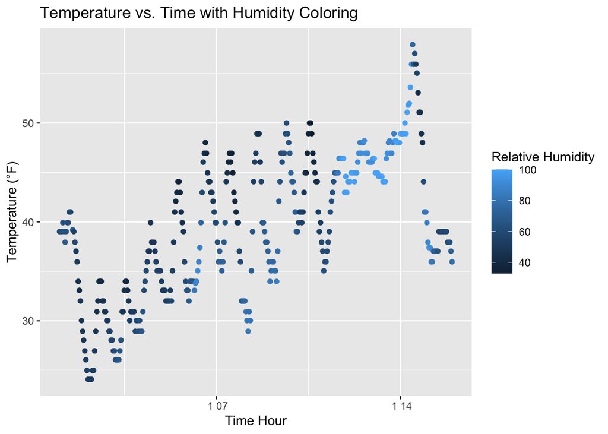

# Problem 2

### Data frame creation:

```
## # A tibble: 10 × 4
##       nor log   char  factor
##     <dbl> <lgl> <chr> <fct>
##  1 -0.626 FALSE a     level1
##  2  0.184 TRUE  b     level3
##  3 -0.836 FALSE c     level1
##  4  1.60  TRUE  d     level1
##  5  0.330 TRUE  e     level1
##  6 -0.820 FALSE f     level1
##  7  0.487 TRUE  g     level2
##  8  0.738 TRUE  h     level1
##  9  0.576 TRUE  i     level1
## 10 -0.305 FALSE j     level2
```

### When try to directly calculate the mean:

```r
mean(df)
```

```
## Warning in mean.default(df): 参数不是数值也不是逻辑值：回覆NA
```

```
## [1] NA
```

The warning shows some variables in the data frame can’t be directly calculated

### Calculable variables:

```r
mean_normal <- mean(df %>% pull(nor))
mean_logical <- mean(df %>% pull(log), na.rm = TRUE)
```

The mean value of the sample from normal distribution is 0.1322028

The mean value of the logical vector is 0.6

### For the following tow variables, the mean fuction would return “NA”

```r
mean_character <- mean(df %>% pull(char))
mean_factor <- mean(df %>% pull(factor))
```

### To convert variables to numeric

Use `as.numeric`

```
numeric_logical <- as.numeric(df$log)
numeric_character <- as.numeric(df$char)
numeric_factor <- as.numeric(df$factor)
```

For the logical variables, it would converted to 0 and 1 corresponding to `T` and `F`

For the character variables, `NA` would be incurred as a replacement of all the characters

For the factor variables, the levels of factors would convert to numeric value 1, 2 and 3

In that case, character wouldn’t convert to the numeric variable which explain the warning produced when using `mean` function.